# Lesson 190 · Research-gap checkpoint

Year 5 · Q3 checkpoint · Evidence before ambition

You have seen models, temporal audits, serving simulations and privacy mechanisms. Now turn that work into **one research question that an experiment could disprove**. This serves the mission: make the relational-learning thesis legible to a skeptical reader.

**Tangible win:** write a claim whose scope matches its evidence, then specify the next observation that could change your mind. Read the short core in about 15 minutes; complete the notebook and written defense separately.

**Selected replay COMPLETE.** Fresh training NOT_RUN; novelty NOT_ESTABLISHED. The research checkpoint remains INCOMPLETE and the learner PENDING_WRITTEN_DEFENSE.

[Lesson 181](https://avistian.github.io/relational/lessons/0181-relbench-v2-autocomplete.html) supplies the autocomplete contract. [Lesson 182](https://avistian.github.io/relational/lessons/0182-rdb-pfn-composite-message-passing.html) separates a reproduced comparison from a proposed hybrid. [Lesson 188](https://avistian.github.io/relational/lessons/0188-systematic-literature-tracking.html) separates collected papers from complete discovery. [Lesson 189’s draft problem-ranking work](https://avistian.github.io/relational/lessons/0189-identify-open-problems.html) is an optional bridge; the three cards below make this checkpoint self-contained, without assuming you completed it.

## 1 · State the claim and its population

**Vocabulary for the checkpoint.** A claim is a statement the evidence may support. An **estimand** is the exact quantity an experiment aims to estimate. A **paired contrast** compares outcomes for matched queries and training seeds, so the comparison shares those sources of variation. A **falsifier** is a result specified in advance that would count against the claim. The proposed study below is a plan, not a completed experiment.

## 2 · Walk from bytes to a sentence

For each saved run, authenticate its receipt; match every `(entity_id, cutoff)` to the released test labels; verify the full support draw; then score. Check the entire declared grid before computing a mean. Dropping an inconvenient seed changes the experiment.

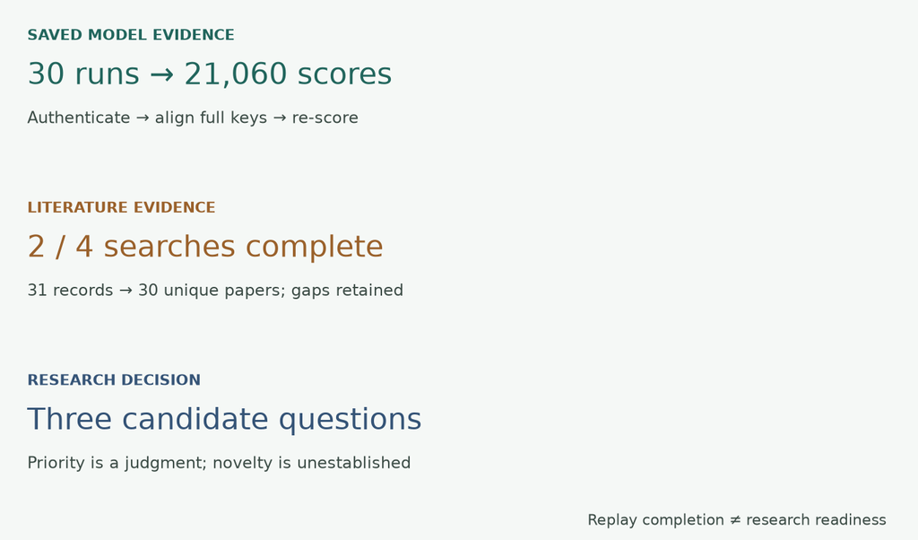

Measured replay boundaries: a complete selected model replay, incomplete literature coverage and an authored research decision remain separate.

RDBPFN uses relational synthetic-prior pretraining; RDBPFN_single is its single-table-prior control; TabICLv1.1 is the released tabular comparator. All three consume the same released DFS feature interface. A composite route joins a source entity through an intermediate row to a destination; that route is not introduced by this replay.

The chosen published comparison is **RDB-PFN v5 Table 9, rel-f1/driver-dnf**, with three released models, ten paired support draws, 512 support rows and all 702 test queries. L190 replays all 21,060 saved predictions from L182. It does not load a model or repeat pretraining. The released DFS features and label orientation are retained. Reconstructing raw labels, historical feature availability and DFS from the database are outside this replay. See the [versioned primary paper](https://arxiv.org/html/2603.03805v5) and [frozen protocol](https://avistian.github.io/relational/labs/l190-reproduction.md).

| Saved model | Mean AUROC | Sample SD across support draws |
| --- | --- | --- |
| RDBPFN | 0.721938 | 0.019983 |
| RDBPFN_single | 0.663990 | 0.034177 |
| TabICLv1.1 | 0.717568 | 0.009770 |

**Worked trace:** for two positive scores `[0.9, 0.5]` and two negative scores `[0.1, 0.5]`, there are four positive–negative pairs. Three wins plus half credit for one tie give AUROC `3.5 / 4 = 0.875`. The real implementation uses average ranks, then an independent verifier counts pairs directly. Query keys align the scores; row order never establishes identity.

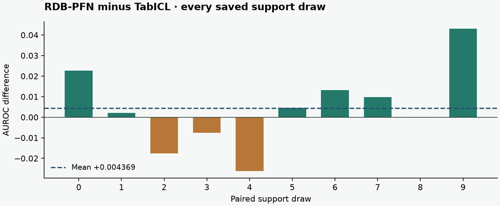

Measured AUROC differences on the same frozen test population. All ten paired support draws shown; six are positive. No database-level confidence claim.

**Write this:** “On the frozen F1 task and paired support draws, the saved RDB-PFN mean AUROC exceeds the saved TabICL mean by 0.004369; the difference is positive in 6/10 draws.” This is descriptive variation over support draws, not a confidence interval for performance on new databases. [Executable replay](https://avistian.github.io/relational/labs/_replay_l190.py) · [independent checks](https://avistian.github.io/relational/labs/_verify_l190_results.json).

**Read average gain and win count separately.** These invented ten-draw contrasts are AUROC differences, model A minus model B, not additional benchmark runs:

| Paired differences | A wins | Mean |
| --- | --- | --- |
| Nine +0.001; one −0.020 | 9/10 | −0.0011 |
| One +0.020; nine −0.001 | 1/10 | +0.0011 |

In the first row, `(9 × 0.001 − 0.020)/10 = −0.0011`: frequent small gains do not outweigh one larger loss. The second reverses every sign. Win count records frequency; mean records signed magnitude. Reporting both reveals behavior that either alone hides. Neither table row establishes transfer to a new database.

**Transfer the trace.** Replace the first row's −0.020 by −0.009. The mean becomes zero while A still wins nine draws. Explain why “usually wins” and “positive average gain” are different claims before writing the actual frozen result above.

**Do not infer:** novel hybrid, database transfer, fresh training, or general superiority. Composite message passing already exists in [RelGNN](https://arxiv.org/html/2502.06784v2). Combining two existing ideas needs a precise insertion point, compatible training and a matched control.

## 3 · Break the claim deliberately

Try removing complete coverage while leaving authentication intact. A correct hash can identify an incomplete packet. Next ask for novelty with all checks enabled. Metric evidence still cannot answer that question.

**Try in Python:** remove one gate flag, then request a novelty claim. The complete saved-metric example is SUPPORTED_REPLAY. Missing any required check makes it BLOCKED. Fresh training is NOT_RUN; novelty and general superiority are NOT_ESTABLISHED.

The four controls are **hypothetical evidence scenarios**; they do not alter the frozen artifacts or the actual checkpoint status. The Python `claim_gate` contract used in the notebook is shown below.

```
def claim_gate(kind, evidence):
    """Only the named saved metric is admissible from this replay's four checks."""
    if kind=='saved_metric':
        required=['authenticated','complete','metric_checked','comparable']
        return 'SUPPORTED_REPLAY' if all(evidence.get(k) is True for k in required) else 'BLOCKED'
    if kind=='fresh_training':return 'NOT_RUN'
    if kind in ['novelty','general_superiority']:return 'NOT_ESTABLISHED'
    raise ValueError('Unknown claim kind')
```

## 4 · Rank questions, then test the ranking

**What changed since L189?** This checkpoint uses a separate authored shortlist. It retains availability and composite structure, but replaces cross-database pretraining with joint serving/privacy constraints to synthesize Lessons 186–187. Its composite proposal contrasts scratch versus pretrained initialization; L182/L189 instead emphasize the synthetic-prior and encoder choices. These are different experiments. The 27 weight settings below rank this checkpoint’s three cards; they do not extend or independently confirm L189’s ranking. Keeping the earlier shortlist visible makes the change a decision to defend.

**Availability-aware autocomplete.** The apparent benefit of relational context shrinks when context must be available by the query cutoff. Existing query keys and audits make a paired information-access test easy to specify. True arrival histories remain missing.

**Composite structure in a foundation learner.** Adding composite routes interacts positively with relational pretraining under matched compute. High potential relevance, but inserting routes changes the model and invalidates direct checkpoint reuse.

**Accuracy under serving and privacy constraints.** A declared relational pipeline retains useful accuracy subject to fixed freshness, latency and entity-level privacy constraints. Requires real latency, availability histories, a privacy unit, and a bounded release/training mechanism; existing simulations do not measure their joint utility.

The scores are authored judgments on a 1–5 scale, not measurements. Priority is `impact × weighted mean(data, implementation, compute feasibility)`. High feasibility means easier to investigate. Inspect the rationale before accepting a score; changing weights alone cannot test whether the scores are wrong.

**Try in Python:** call rank_cases(cases), inspect all weights and alter an authored score. With equal weights, availability scores 18.667, composite structure 15.000 and joint constraints 10.667. Availability leads all 27 tested weight triples. Novelty and execution cost remain NOT_ESTABLISHED.

Availability wins all 27 weight triples drawn from `{1,2,3}`. That is stability within this rubric, not evidence it will yield a publishable result. [Lesson 186](https://avistian.github.io/relational/lessons/0186-production-constraints.html) provides serving simulations and [Lesson 187](https://avistian.github.io/relational/lessons/0187-ethics-privacy-reg.html) illustrates entity-level privacy boundaries. Their numerical experiments are not rerun here; their frozen status receipts explicitly limit the joint-constraints proposal.

## 5 · Read the five-page research document

Open the **[worked document](https://avistian.github.io/relational/reference/research-gap-document.html)** or its **[five-page PDF](https://avistian.github.io/relational/reference/research-gap-document.pdf)**. The pages answer five different questions:

1. What narrow question follows from the mission?
2. What evidence actually supports it?
3. Which alternatives were considered, and why this ranking?
4. What paired experiment could falsify the leading hypothesis?
5. What is missing, and what decision follows?

**Read the proposed uncertainty calculation.** Mean absolute error (**MAE**) averages prediction distances from the true finishing positions; lower is better. A **bootstrap** repeatedly resamples observed units to explore how an estimate varies. Resampling whole driver clusters keeps one driver’s repeated cutoffs together. The proposed interval concerns those drivers on this task, not unseen databases.

The leading design compares event-time visibility with measured availability visibility on identical autocomplete queries. Genuine arrival histories are an admission requirement. Artificial delays can test a mechanism, but cannot stand in for the historical experiment. A model defect that prevents fitting is an engineering blocker; it does not establish a research gap.

The literature packet reconstructs 31 received records and 30 unique papers from two complete searches. Two other searches failed. A replay can reproduce that finding exactly; it cannot recover the missing literature. Therefore the document labels novelty **NOT_ESTABLISHED**. [L188 raw collection receipt](https://avistian.github.io/relational/labs/evidence/l190/packet/literature/collection.json).

## 6 · Implement, challenge, defend

[Student notebook](https://avistian.github.io/relational/labs/0190-research-gap-checkpoint.ipynb) · [executed solution](https://avistian.github.io/relational/labs/solutions/0190-research-gap-checkpoint.ipynb) · [readable executed lab](https://avistian.github.io/relational/labs/html/0190-research-gap-checkpoint.html) · [field guide](https://avistian.github.io/relational/reference/research-gap-checkpoint.html).

Implement three live contracts: complete-key AUROC, a conservative claim gate, and exhaustive ranking sensitivity. The full replay calls your functions. CHECK examples include ties, shuffled rows, omitted predictions and tied proposals. The portable packet contains the original saved arrays and raw literature responses; no network or cloud account is required. NumPy is the only replay dependency beyond Python's standard library.

```
.venv/bin/python labs/_budget_l190.py .venv/bin/python labs/_replay_l190.py
.venv/bin/python labs/_budget_l190.py .venv/bin/python labs/_verify_l190.py
```

The aggregate local runtime cap is 1,800 seconds, including failures and validation; new cloud/API spend is $0. An interrupted reservation requires reconciliation before another run. The [budget ledger](https://avistian.github.io/relational/labs/evidence/l190/local-budget.json) records attempts. Do not overwrite the frozen input packet to make a failure disappear.

**EXIT:** submit your own five-page document with a narrow claim, cited evidence, three justified alternatives, a paired estimand and falsifier, an aggregate budget, and explicit unknowns. Name one result that would reverse your priority ranking. An automatic replay cannot grade the scientific argument. Author preparation is complete only when delivery checks pass; your checkpoint stays `INCOMPLETE` / `PENDING_WRITTEN_DEFENSE` until the teacher reviews your work.

Write your defense in the EXIT cell below.

Draft only; this field is not submitted or saved. Copy your text into your own document.

Tomorrow, restate the three evidence distinctions without looking. In one week, revisit the ranking after reading a disconfirming primary source. Ask the teaching agent any follow-up question, especially where an evidence boundary or proposed control is unclear.

**Next: experiment tracking.** Turn this document’s declared data, settings, costs and artifacts into a run record before executing the proposed study. Use the [course sequence](https://avistian.github.io/relational/reference/curriculum.html) to continue when Lesson 191 is ready.

## PROVIDED · Offline packet

Python 3 + NumPy. Colab normally includes NumPy; another clean Python environment can install it with `python3 -m pip install numpy`. No model downloads, repository checkout, cloud account or network access is needed for this replay. The payload contains real original saved arrays and raw literature responses, not generated replacement data.

```python
import base64, hashlib, io, itertools, json, math, tempfile, zipfile
from fractions import Fraction
from pathlib import Path
import numpy as np
workspace=Path(tempfile.mkdtemp(prefix="l190-replay-"))
```

## TODO · keyed_auc

Align complete (entity, cutoff) identities; reject duplicates/nonfinite values; give half credit for ties. Predict a failure case first.

```python
def keyed_auc(truth, predictions):
    """Rank AUROC with half credit for ties, aligned by (entity_id, cutoff)."""
    def index(rows):
        result={}
        for row in rows:
            if len(row)!=3:raise ValueError('Expected entity, cutoff, value')
            a,b,v=row;key=(a,b)
            if key in result or not math.isfinite(v):raise ValueError('Duplicate key or nonfinite value')
            result[key]=v
        return result
    labels=index(truth);probs=index(predictions)
    if not labels or labels.keys()!=probs.keys():raise ValueError('Incomplete query identity')
    if set(labels.values())!={0,1}:raise ValueError('Both binary classes required')
    if any(not 0<=v<=1 for v in probs.values()):raise ValueError('Probabilities outside [0,1]')
    ordered=sorted((probs[k],labels[k]) for k in labels)
    rank_sum=0.;i=0
    while i<len(ordered):
        j=i+1
        while j<len(ordered) and ordered[j][0]==ordered[i][0]:j+=1
        rank_sum+=((i+1+j)/2)*sum(y for _,y in ordered[i:j]);i=j
    npos=sum(labels.values());nneg=len(labels)-npos
    return (rank_sum-npos*(npos+1)/2)/(npos*nneg)
```

### CHECK · Synthetic examples

```python
truth=[(1,10,0),(1,20,1),(2,10,1),(2,20,0)]
pred=[(2,20,.5),(1,20,.9),(1,10,.1),(2,10,.5)]
assert keyed_auc(truth,pred)==.875
try:
    keyed_auc(truth,pred[:-1])
except ValueError:
    pass
else:
    raise AssertionError('Incomplete predictions accepted')
print("Contract examples PASS")
```

```
Contract examples PASS
```

## TODO · claim_gate

Implement the conservative four-check saved-metric gate. The other claim kinds stay unestablished or unrun. Predict a failure case first.

```python
def claim_gate(kind, evidence):
    """Only the named saved metric is admissible from this replay's four checks."""
    if kind=='saved_metric':
        required=['authenticated','complete','metric_checked','comparable']
        return 'SUPPORTED_REPLAY' if all(evidence.get(k) is True for k in required) else 'BLOCKED'
    if kind=='fresh_training':return 'NOT_RUN'
    if kind in ['novelty','general_superiority']:return 'NOT_ESTABLISHED'
    raise ValueError('Unknown claim kind')
```

### CHECK · Synthetic examples

```python
e=dict(authenticated=True,complete=True,metric_checked=True,comparable=True)
assert claim_gate('saved_metric',e)=='SUPPORTED_REPLAY'
assert claim_gate('saved_metric',dict(e,complete=False))=='BLOCKED'
assert claim_gate('novelty',e)=='NOT_ESTABLISHED'
print("Contract examples PASS")
```

```
Contract examples PASS
```

## TODO · rank_cases

Return all 27 weight triples, per-case priorities and all tied leaders. Validate the ordinal scores. Predict a failure case first.

```python
def rank_cases(cases):
    """Author-assigned ordinal rubric; exhaustive weight sensitivity, ties retained."""
    ids=[c['id'] for c in cases]
    if not ids or any(not isinstance(k,str) or not k for k in ids) or len(set(ids))!=len(ids):
        raise ValueError('Nonempty unique case IDs required')
    for c in cases:
        vals=[c['impact']]+c['feasibility']
        if len(vals)!=4 or any(type(v) is not int or not 1<=v<=5 for v in vals):
            raise ValueError('Impact and three feasibility scores must be integers 1..5')
    rows=[]
    for weights in itertools.product([1,2,3],repeat=3):
        scores={c['id']:Fraction(c['impact']*sum(a*b for a,b in zip(c['feasibility'],weights)),sum(weights)) for c in cases}
        best=max(scores.values())
        rows.append(dict(weights=list(weights),scores={k:float(v) for k,v in scores.items()},leaders=sorted(k for k,v in scores.items() if v==best)))
    return rows
```

### CHECK · Synthetic examples

```python
ranking=rank_cases(cases)
assert len(ranking)==27
assert all(row['leaders']==['availability'] for row in ranking)
tie=[cases[0],dict(cases[0],id='copy')]
assert rank_cases(tie)[0]['leaders']==['availability','copy']
print("Contract examples PASS")
```

```
Contract examples PASS
```

## PROVIDED · Full replay operator

Read the identity and support checks before running. This calls your functions and refuses missing runs. Source label reconstruction and fresh model inference are outside its scope.

```python
def replay190(packet, manifest, score, gate, rank):
    import hashlib,json,math,statistics,xml.etree.ElementTree as ET
    from pathlib import Path
    import numpy as np
    q=Path(packet).resolve()
    actual={str(p.relative_to(q)) for p in q.rglob('*') if p.is_file()}
    if actual!=set(manifest['files']):raise ValueError('Input file set differs')
    for name,digest in manifest['files'].items():
        p=(q/name).resolve()
        if not p.is_relative_to(q) or hashlib.sha256(p.read_bytes()).hexdigest()!=digest:
            raise ValueError('Input identity differs: '+name)
    read=lambda name:json.loads((q/name).read_text())
    expected={(a,s) for a in ['RDBPFN','RDBPFN_single','TabICLv1.1'] for s in range(10)}
    seen=set();runs=[];by={a:{} for a,s in expected}
    with np.load(q/'model/prepared.npz',allow_pickle=False) as z:
        truth=[(int(a),int(b),int(y)) for (a,b),y in zip(z['test_keys'],z['y_test'])]
        if len(truth)!=702 or len(set((a,b) for a,b,_ in truth))!=702:raise ValueError('Wrong released query population')
        support_ref={s:z['train_keys'][z['support'][s]].tolist() for s in range(10)}
    for folder in ['pilot-1','full-1']:
        receipt=read('model/'+folder+'/receipt.json')
        for record in receipt['records']:
            arm,seed=record['arm'],record['seed'];identity=(arm,seed)
            if identity not in expected or identity in seen:raise ValueError('Duplicate or unexpected run')
            seen.add(identity);path=q/'model'/folder/f'{arm}-{seed}.npz'
            if hashlib.sha256(path.read_bytes()).hexdigest()!=record['sha256']:raise ValueError('Prediction receipt mismatch')
            with np.load(path,allow_pickle=False) as x:
                keys=x['keys'].tolist();labels=x['label'].tolist();prob=x['probability'].tolist();support=x['support_keys'].tolist()
            if keys!=[[a,b] for a,b,y in truth] or labels!=[y for a,b,y in truth]:raise ValueError('Released labels/keys differ')
            if support!=support_ref[seed] or len(support)!=512 or len(set(map(tuple,support)))!=512:raise ValueError('Support draw differs')
            if set(map(tuple,keys))&set(map(tuple,support)):raise ValueError('Support/test overlap')
            if max(b for a,b in support)>=min(b for a,b in keys):raise ValueError('Support cutoff reaches test queries')
            if len(prob)!=702 or record['rows']!=702 or record['support']!=512:raise ValueError('Incomplete population')
            auc=score(truth,[(a,b,p) for (a,b),p in zip(keys,prob)])
            if not math.isfinite(auc) or abs(auc-record['auc'])>1e-12:raise ValueError('Metric differs from receipt')
            by[arm][seed]=auc;runs.append(dict(arm=arm,seed=seed,auc=auc,queries=len(keys),support=len(support)))
    if seen!=expected:raise ValueError('Incomplete evaluation grid')
    inherited=read('reports/l182.json');models={}
    for arm,values in sorted(by.items()):
        v=[values[s] for s in range(10)];mean=statistics.mean(v);sd=statistics.stdev(v)
        if abs(mean-inherited['models'][arm]['mean'])>1e-12:raise ValueError('Inherited mean differs')
        if abs(sd-inherited['models'][arm]['sample_sd'])>1e-12:raise ValueError('Inherited dispersion differs')
        models[arm]=dict(mean=mean,sample_sd=sd,per_seed=v)
    diff=[by['RDBPFN'][s]-by['TabICLv1.1'][s] for s in range(10)]
    paired=dict(mean=statistics.mean(diff),sample_sd=statistics.stdev(diff),positive=sum(d>0 for d in diff),per_seed=diff)
    # Independently read raw Atom, using the frozen first-submission window.
    config=read('literature/config.json');receipt=read('literature/collection.json')
    atom='{http://www.w3.org/2005/Atom}';op='{http://a9.com/-/spec/opensearch/1.1/}'
    all_ids=set();queries={};received=0
    import re
    for query in config['queries']:
        pages=[]
        for attempt in receipt['attempts']:
            if attempt['kind']!=query['name'] or not attempt.get('accepted'):continue
            raw=(q/'literature'/attempt['file']).read_bytes()
            if hashlib.sha256(raw).hexdigest()!=attempt['sha256']:raise ValueError('Raw response receipt mismatch')
            root=ET.fromstring(raw)
            if root.tag!=atom+'feed':raise ValueError('Not an Atom feed')
            total=int(root.findtext(op+'totalResults'));offset=int(root.findtext(op+'startIndex'))
            if offset!=attempt['start']:raise ValueError('Request/response offset differs')
            ids=[];dates_ok=True
            for e in root.findall(atom+'entry'):
                ident=e.findtext(atom+'id').rsplit('/',1)[-1];ident=re.sub(r'v[1-9][0-9]*$','',ident)
                if not re.fullmatch(r'\d{4}\.\d{4,5}',ident):raise ValueError('Unexpected modern arXiv identity')
                ids.append(ident);all_ids.add(ident)
                date=e.findtext(atom+'published');dates_ok &= '2026-07-01T00:00:00Z'<=date<'2026-10-01T00:00:00Z'
            pages.append((offset,total,ids,dates_ok));received+=len(ids)
        cursor=0;unique=set();complete=bool(pages);total=pages[0][1] if pages else None
        for offset,t,ids,dates_ok in sorted(pages):
            complete &= offset==cursor and t==total and dates_ok and len(ids)==len(set(ids)) and not bool(unique.intersection(ids))
            if not ids and total!=0:complete=False
            unique.update(ids);cursor+=len(ids)
        complete &= cursor==total
        queries[query['name']]=dict(status='COMPLETE' if complete else 'INCOMPLETE',received=cursor,total=total)
    lit=dict(queries=queries,complete_queries=sum(v['status']=='COMPLETE' for v in queries.values()),query_count=len(queries),received_records=received,unique_papers=len(all_ids),failed_attempts=sum(not a.get('ok') for a in receipt['attempts']),collection_status='COMPLETE' if all(v['status']=='COMPLETE' for v in queries.values()) else 'INCOMPLETE')
    old=read('reports/l188.json')
    if lit['unique_papers']!=old['unique_papers'] or lit['collection_status']!=old['collection_status']:raise ValueError('Literature report differs')
    cases=read('cases.json')
    if any(c['novelty']!='NOT_ESTABLISHED' or c['cost']!='NOT_ESTABLISHED' for c in cases):raise ValueError('Unestablished proposal promoted')
    ranking=rank(cases)
    checks=dict(authenticated=True,complete=True,metric_checked=True,comparable=True,novelty_reviewed=False)
    decisions={kind:gate(kind,checks) for kind in ['saved_metric','fresh_training','novelty','general_superiority']}
    required=dict(saved_metric='SUPPORTED_REPLAY',fresh_training='NOT_RUN',novelty='NOT_ESTABLISHED',general_superiority='NOT_ESTABLISHED')
    if decisions!=required:raise ValueError('Claim gate promoted evidence')
    keys={181:['selected_experiment','gnn_status','historical_identity'],182:['status','hybrid_training','whole_paper'],183:['relgt_full_reproduction','griffin_full_reproduction'],184:['selected_experiment','fresh_training'],185:['status','real_world_causality'],186:['status'],187:['production_dp','erasure'],188:['collection_status','replay_status']}
    status_receipts={str(n):{k:read(f'reports/l{n}.json')[k] for k in fields} for n,fields in keys.items()}
    return dict(experiment='L190 Q3 Research-Gap Evidence Replay',replay='COMPLETE',authenticated_files=len(actual),runs=sorted(runs,key=lambda r:(r['arm'],r['seed'])),prediction_rows=sum(r['queries'] for r in runs),models=models,paired_rdbpfn_minus_tabicl=paired,literature=lit,ranking=ranking,claims=decisions,inherited_status_receipts=status_receipts,other_lesson_numerics='NOT_REPLAYED',source_labels_and_DFS='RELEASED_ARTIFACTS_ONLY',historical_availability='NOT_ESTABLISHED',novelty='NOT_ESTABLISHED',future_experiment='NOT_RUN',checkpoint='INCOMPLETE',learner='PENDING_WRITTEN_DEFENSE',cloud_usd=0)
```

## CHECK · All real saved evidence

Authenticate every input and process every run/page; compare the whole report.

```python
report=replay190(packet,manifest,keyed_auc,claim_gate,rank_cases)
assert report==json.loads('{"authenticated_files": 64, "checkpoint": "INCOMPLETE", "claims": {"fresh_training": "NOT_RUN", "general_superiority": "NOT_ESTABLISHED", "novelty": "NOT_ESTABLISHED", "saved_metric": "SUPPORTED_REPLAY"}, "cloud_usd": 0, "experiment": "L190 Q3 Research-Gap Evidence Replay", "future_experiment": "NOT_RUN", "historical_availability": "NOT_ESTABLISHED", "inherited_status_receipts": {"181": {"gnn_status": "NOT_RUN_TRAINING_HEALTH_GATE", "historical_identity": "NOT_ESTABLISHED", "selected_experiment": "INCOMPLETE"}, "182": {"hybrid_training": "NOT_RUN", "status": "COMPLETE_SELECTED_REPRODUCTION", "whole_paper": "NOT_RUN"}, "183": {"griffin_full_reproduction": "INCOMPLETE_BUDGET_GATE", "relgt_full_reproduction": "INCOMPLETE_TEMPORAL_AND_BUDGET_GATES"}, "184": {"fresh_training": "NOT_RUN", "selected_experiment": "INCOMPLETE_SOURCE_TEMPORAL_GATE"}, "185": {"real_world_causality": "NOT_ESTABLISHED", "status": "COMPLETE_SYNTHETIC_EXPERIMENT"}, "186": {"status": "COMPLETE_COURSE_SIMULATION"}, "187": {"erasure": "NOT_ESTABLISHED", "production_dp": "NOT_ESTABLISHED"}, "188": {"collection_status": "INCOMPLETE", "replay_status": "COMPLETE"}}, "learner": "PENDING_WRITTEN_DEFENSE", "literature": {"collection_status": "INCOMPLETE", "complete_queries": 2, "failed_attempts": 4, "queries": {"relational": {"received": 0, "status": "INCOMPLETE", "total": null}, "relbench": {"received": 9, "status": "COMPLETE", "total": 9}, "tabarena": {"received": 22, "status": "COMPLETE", "total": 22}, "tabular": {"received": 0, "status": "INCOMPLETE", "total": null}}, "query_count": 4, "received_records": 31, "unique_papers": 30}, "models": {"RDBPFN": {"mean": 0.7219377348362855, "per_seed": [0.7383984775289123, 0.7175523349436392, 0.7038598545844923, 0.7255941053042503, 0.6823598301859172, 0.7242277850973503, 0.7217342507197579, 0.7440491875274484, 0.7114917288830332, 0.7501097935880544], "sample_sd": 0.019982667847990538}, "RDBPFN_single": {"mean": 0.6639896550041477, "per_seed": [0.6116234811886986, 0.687180988630264, 0.6655638510710975, 0.6885375494071146, 0.6797443029327087, 0.6583711511247743, 0.6154686966281169, 0.6305274971941639, 0.6955838579026985, 0.7072951739618406], "sample_sd": 0.03417677717319856}, "TabICLv1.1": {"mean": 0.7175684380032206, "per_seed": [0.7156687649441272, 0.7155370126384619, 0.7214658663934026, 0.7332552578929391, 0.7085541404381984, 0.7196750109793588, 0.7084663055677548, 0.7342263211828429, 0.7117747523544625, 0.7070609476406577], "sample_sd": 0.00976959545029791}}, "novelty": "NOT_ESTABLISHED", "other_lesson_numerics": "NOT_REPLAYED", "paired_rdbpfn_minus_tabicl": {"mean": 0.00436929683306495, "per_seed": [0.022729712584785067, 0.002015322305177314, -0.017606011808910305, -0.007661152588688824, -0.02619431025228125, 0.004552774117991487, 0.013267945152003136, 0.009822866344605496, -0.00028302347142927786, 0.04304884594739666], "positive": 6, "sample_sd": 0.0198077949697135}, "prediction_rows": 21060, "ranking": [{"leaders": ["availability"], "scores": {"availability": 18.666666666666668, "composite": 15.0, "constraints": 10.666666666666666}, "weights": [1, 1, 1]}, {"leaders": ["availability"], "scores": {"availability": 19.0, "composite": 16.25, "constraints": 10.0}, "weights": [1, 1, 2]}, {"leaders": ["availability"], "scores": {"availability": 19.2, "composite": 17.0, "constraints": 9.6}, "weights": [1, 1, 3]}, {"leaders": ["availability"], "scores": {"availability": 18.0, "composite": 13.75, "constraints": 11.0}, "weights": [1, 2, 1]}, {"leaders": ["availability"], "scores": {"availability": 18.4, "composite": 15.0, "constraints": 10.4}, "weights": [1, 2, 2]}, {"leaders": ["availability"], "scores": {"availability": 18.666666666666668, "composite": 15.833333333333334, "constraints": 10.0}, "weights": [1, 2, 3]}, {"leaders": ["availability"], "scores": {"availability": 17.6, "composite": 13.0, "constraints": 11.2}, "weights": [1, 3, 1]}, {"leaders": ["availability"], "scores": {"availability": 18.0, "composite": 14.166666666666666, "constraints": 10.666666666666666}, "weights": [1, 3, 2]}, {"leaders": ["availability"], "scores": {"availability": 18.285714285714285, "composite": 15.0, "constraints": 10.285714285714286}, "weights": [1, 3, 3]}, {"leaders": ["availability"], "scores": {"availability": 19.0, "composite": 15.0, "constraints": 11.0}, "weights": [2, 1, 1]}, {"leaders": ["availability"], "scores": {"availability": 19.2, "composite": 16.0, "constraints": 10.4}, "weights": [2, 1, 2]}, {"leaders": ["availability"], "scores": {"availability": 19.333333333333332, "composite": 16.666666666666668, "constraints": 10.0}, "weights": [2, 1, 3]}, {"leaders": ["availability"], "scores": {"availability": 18.4, "composite": 14.0, "constraints": 11.2}, "weights": [2, 2, 1]}, {"leaders": ["availability"], "scores": {"availability": 18.666666666666668, "composite": 15.0, "constraints": 10.666666666666666}, "weights": [2, 2, 2]}, {"leaders": ["availability"], "scores": {"availability": 18.857142857142858, "composite": 15.714285714285714, "constraints": 10.285714285714286}, "weights": [2, 2, 3]}, {"leaders": ["availability"], "scores": {"availability": 18.0, "composite": 13.333333333333334, "constraints": 11.333333333333334}, "weights": [2, 3, 1]}, {"leaders": ["availability"], "scores": {"availability": 18.285714285714285, "composite": 14.285714285714286, "constraints": 10.857142857142858}, "weights": [2, 3, 2]}, {"leaders": ["availability"], "scores": {"availability": 18.5, "composite": 15.0, "constraints": 10.5}, "weights": [2, 3, 3]}, {"leaders": ["availability"], "scores": {"availability": 19.2, "composite": 15.0, "constraints": 11.2}, "weights": [3, 1, 1]}, {"leaders": ["availability"], "scores": {"availability": 19.333333333333332, "composite": 15.833333333333334, "constraints": 10.666666666666666}, "weights": [3, 1, 2]}, {"leaders": ["availability"], "scores": {"availability": 19.428571428571427, "composite": 16.428571428571427, "constraints": 10.285714285714286}, "weights": [3, 1, 3]}, {"leaders": ["availability"], "scores": {"availability": 18.666666666666668, "composite": 14.166666666666666, "constraints": 11.333333333333334}, "weights": [3, 2, 1]}, {"leaders": ["availability"], "scores": {"availability": 18.857142857142858, "composite": 15.0, "constraints": 10.857142857142858}, "weights": [3, 2, 2]}, {"leaders": ["availability"], "scores": {"availability": 19.0, "composite": 15.625, "constraints": 10.5}, "weights": [3, 2, 3]}, {"leaders": ["availability"], "scores": {"availability": 18.285714285714285, "composite": 13.571428571428571, "constraints": 11.428571428571429}, "weights": [3, 3, 1]}, {"leaders": ["availability"], "scores": {"availability": 18.5, "composite": 14.375, "constraints": 11.0}, "weights": [3, 3, 2]}, {"leaders": ["availability"], "scores": {"availability": 18.666666666666668, "composite": 15.0, "constraints": 10.666666666666666}, "weights": [3, 3, 3]}], "replay": "COMPLETE", "runs": [{"arm": "RDBPFN", "auc": 0.7383984775289123, "queries": 702, "seed": 0, "support": 512}, {"arm": "RDBPFN", "auc": 0.7175523349436392, "queries": 702, "seed": 1, "support": 512}, {"arm": "RDBPFN", "auc": 0.7038598545844923, "queries": 702, "seed": 2, "support": 512}, {"arm": "RDBPFN", "auc": 0.7255941053042503, "queries": 702, "seed": 3, "support": 512}, {"arm": "RDBPFN", "auc": 0.6823598301859172, "queries": 702, "seed": 4, "support": 512}, {"arm": "RDBPFN", "auc": 0.7242277850973503, "queries": 702, "seed": 5, "support": 512}, {"arm": "RDBPFN", "auc": 0.7217342507197579, "queries": 702, "seed": 6, "support": 512}, {"arm": "RDBPFN", "auc": 0.7440491875274484, "queries": 702, "seed": 7, "support": 512}, {"arm": "RDBPFN", "auc": 0.7114917288830332, "queries": 702, "seed": 8, "support": 512}, {"arm": "RDBPFN", "auc": 0.7501097935880544, "queries": 702, "seed": 9, "support": 512}, {"arm": "RDBPFN_single", "auc": 0.6116234811886986, "queries": 702, "seed": 0, "support": 512}, {"arm": "RDBPFN_single", "auc": 0.687180988630264, "queries": 702, "seed": 1, "support": 512}, {"arm": "RDBPFN_single", "auc": 0.6655638510710975, "queries": 702, "seed": 2, "support": 512}, {"arm": "RDBPFN_single", "auc": 0.6885375494071146, "queries": 702, "seed": 3, "support": 512}, {"arm": "RDBPFN_single", "auc": 0.6797443029327087, "queries": 702, "seed": 4, "support": 512}, {"arm": "RDBPFN_single", "auc": 0.6583711511247743, "queries": 702, "seed": 5, "support": 512}, {"arm": "RDBPFN_single", "auc": 0.6154686966281169, "queries": 702, "seed": 6, "support": 512}, {"arm": "RDBPFN_single", "auc": 0.6305274971941639, "queries": 702, "seed": 7, "support": 512}, {"arm": "RDBPFN_single", "auc": 0.6955838579026985, "queries": 702, "seed": 8, "support": 512}, {"arm": "RDBPFN_single", "auc": 0.7072951739618406, "queries": 702, "seed": 9, "support": 512}, {"arm": "TabICLv1.1", "auc": 0.7156687649441272, "queries": 702, "seed": 0, "support": 512}, {"arm": "TabICLv1.1", "auc": 0.7155370126384619, "queries": 702, "seed": 1, "support": 512}, {"arm": "TabICLv1.1", "auc": 0.7214658663934026, "queries": 702, "seed": 2, "support": 512}, {"arm": "TabICLv1.1", "auc": 0.7332552578929391, "queries": 702, "seed": 3, "support": 512}, {"arm": "TabICLv1.1", "auc": 0.7085541404381984, "queries": 702, "seed": 4, "support": 512}, {"arm": "TabICLv1.1", "auc": 0.7196750109793588, "queries": 702, "seed": 5, "support": 512}, {"arm": "TabICLv1.1", "auc": 0.7084663055677548, "queries": 702, "seed": 6, "support": 512}, {"arm": "TabICLv1.1", "auc": 0.7342263211828429, "queries": 702, "seed": 7, "support": 512}, {"arm": "TabICLv1.1", "auc": 0.7117747523544625, "queries": 702, "seed": 8, "support": 512}, {"arm": "TabICLv1.1", "auc": 0.7070609476406577, "queries": 702, "seed": 9, "support": 512}], "source_labels_and_DFS": "RELEASED_ARTIFACTS_ONLY"}')
Path("l190-report.json").write_text(json.dumps(report,indent=2))
print("Replay:",report["replay"],"| Predictions:",report["prediction_rows"])
print("Paired difference:",report["paired_rdbpfn_minus_tabicl"]["mean"])
print("Literature:",report["literature"]["collection_status"])
print("Checkpoint:",report["checkpoint"],"| Learner:",report["learner"])
```

```
Replay: COMPLETE | Predictions: 21060
Paired difference: 0.00436929683306495
Literature: INCOMPLETE
Checkpoint: INCOMPLETE | Learner: PENDING_WRITTEN_DEFENSE
```

## EXIT · Your five-page argument

Use the supplied document as a worked example, not as your personal submission. Provide question, quantitative evidence, alternative explanations, a matched experiment/falsifier and limits. A replay pass cannot certify novelty or research judgment. Ask the teacher to review the argument.

```python
submission=dict(learner="PENDING_WRITTEN_DEFENSE",question="",evidence="",alternatives="",matched_experiment="",falsifier="",aggregate_budget="",limitations="",what_changes_my_mind="")
Path("l190-submission.json").write_text(json.dumps(submission,indent=2))
```

```
224
```